# hwk_10

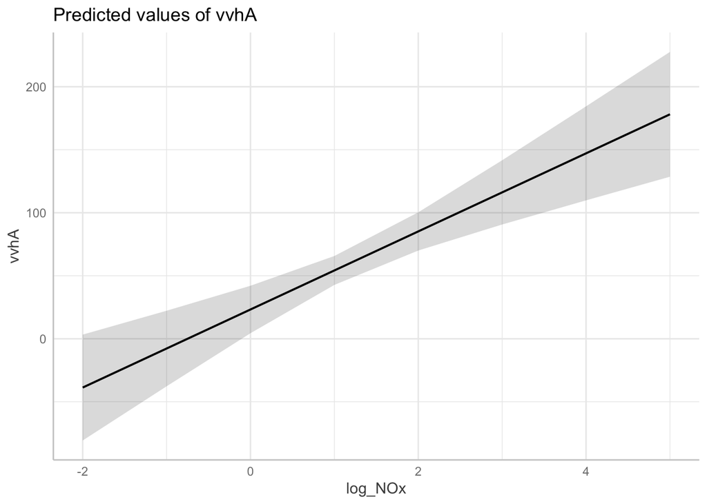

```r
plot(ggeffect(best_model, terms = 'log_NOx')) # pos
```

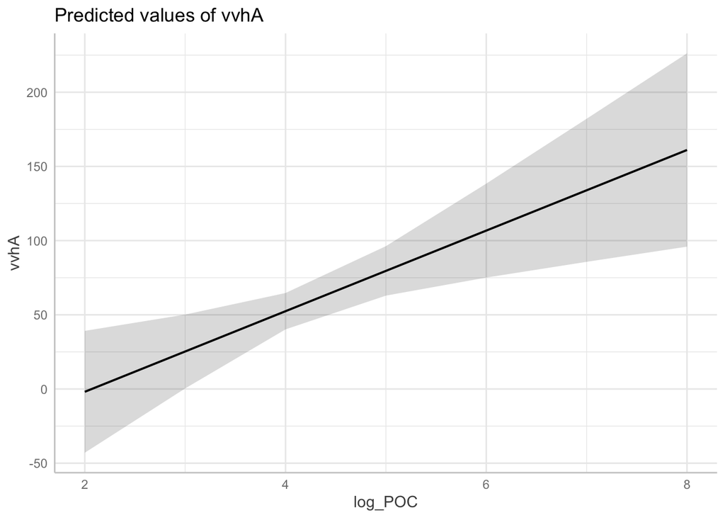

```r
plot(ggeffect(best_model, terms = 'log_POC')) # pos
```

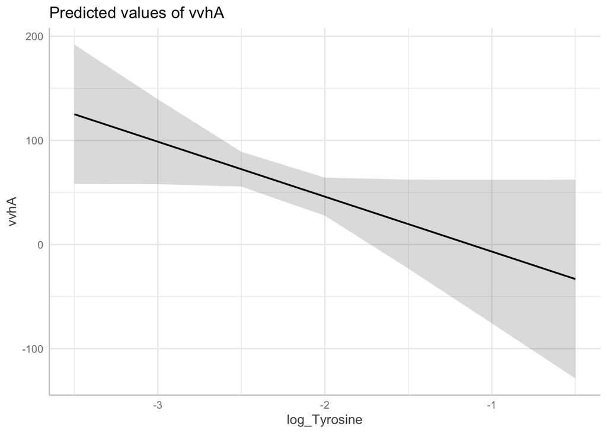

```r
plot(ggeffect(best_model, terms = 'log_Tyrosine')) # neg
```

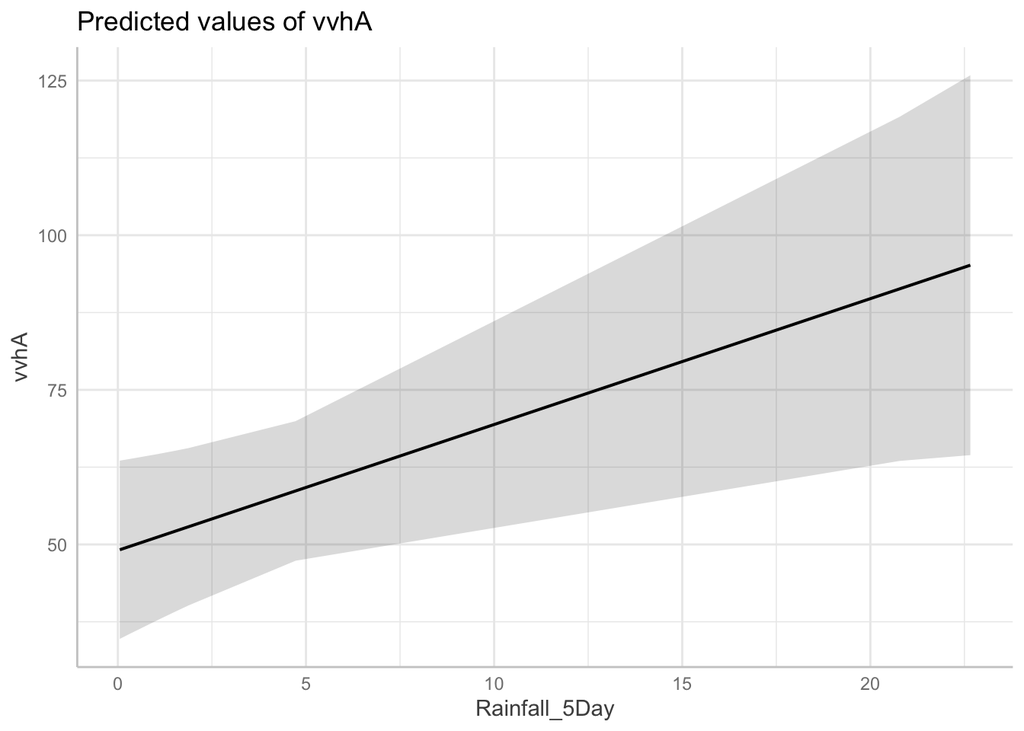

```r
plot(ggeffect(best_model, terms = 'Rainfall_5Day')) # pos
```

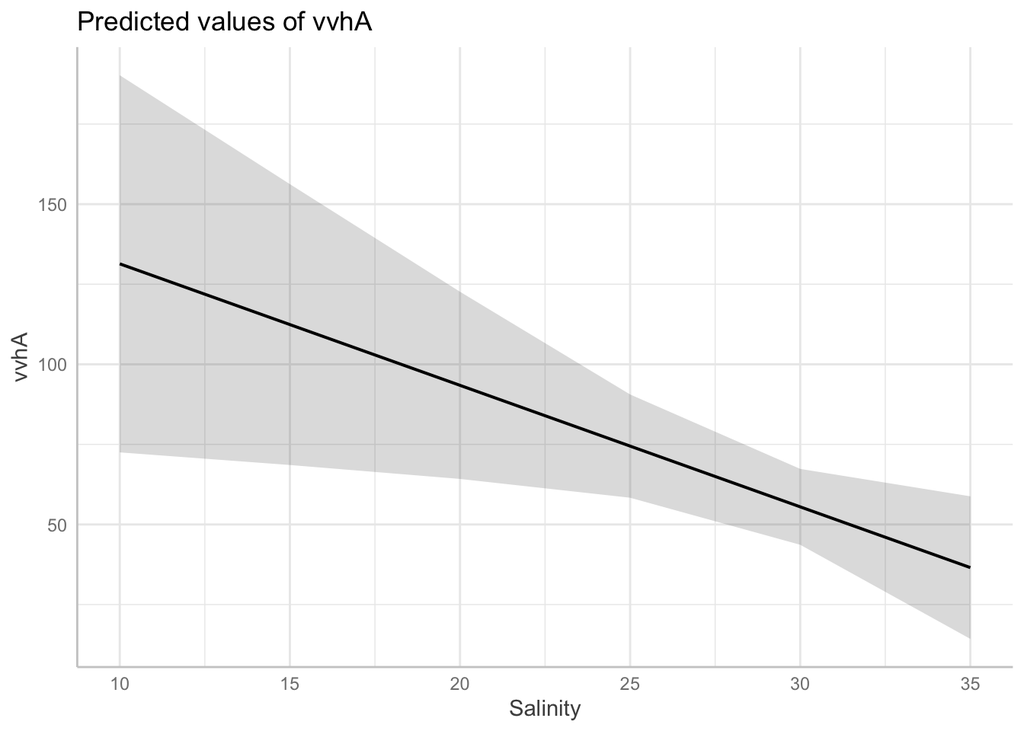

```r
plot(ggeffect(best_model, terms = 'Salinity')) # neg
```

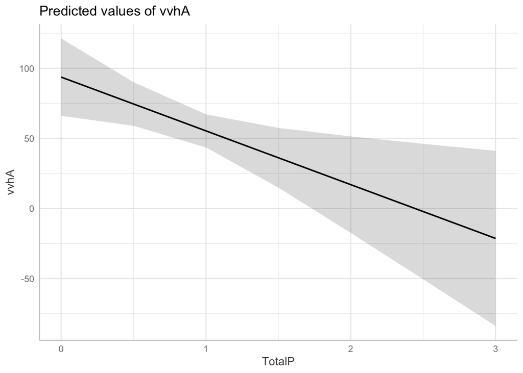

```r
plot(ggeffect(best_model, terms = 'TotalP')) # neg
```

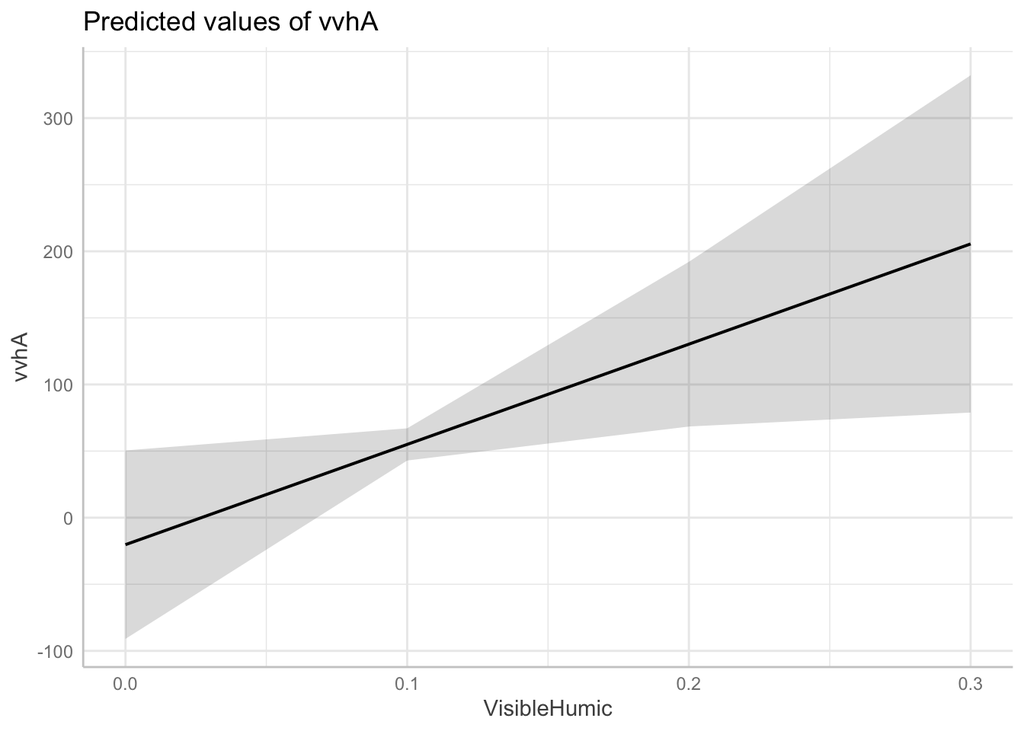

```r
plot(ggeffect(best_model, terms = 'VisibleHumic')) # pos
```

finally! attempt interpretation of results - predictors that we feel confident about having an important effect on vvhA are; HIX log_NOx log_POC Salinity TotalP AirTemp VisibleHumic Rainfall_5Day - There are many other variables which appear to have a significant effect on vvhA if examined individually, but these appear to be less important than the above, which were repeatedly in top performing candidate models.

what mechanisms could underlie strong correlations identified by analysis? - It would make sense that increased Rainfall would drive other predictors. Would be important to test the true independence of rainfall and other predictors. - Increased rainfall is known to decrease salinity, increasing vvhA. Perhaps increased rainfall also decreases HIX which was an important and consistent predictor. - Although I’m not a marine biologist and don’t have internet access to learn more, I would expect rainfall to have wide-ranging effects on nutrient and abiotic conditions on the Ala Wai Canal, a number of which are important for vvhA.